# Zappos Twitter Analysis, Group 13

Andres Olivera, Omar Abdelgelil, Kurt Kusterer

2/6/2020

**About Zappos**

Zappos.com is an online shoe, clothing and accessories retailer founded in San Francisco, USA by Nick Swinmurn with the name Shoesite.com and now it’s based in Las Vegas, USA. With customer service as their mantra and spread into the company’s culture, in less than 10 years the company manage to become a strong player in the e-commerce industry and in July of 2009 Amazon acquired them in a deal worth around $1.2 billion. This move that help the company keep growing and make use of Amazon’s already set up infrastructure for logistics.

Currently, the company has over 2.000 employees, in 2019 made 2 billion dollars in revenue and has kept and stable growth during the last decade. Zappos is devoted to its customers and it’s been recognized for its 24/7 call center. Now, given that we are in the age of social media explosion, we will analyze how the company is performing in Twitter by conducting a Sentiment Analysis and Topic Analysis on the users that when twitting mentioned the company. Also, we give a brief analysis on its followers and the tweets made by company.

**Sentiment Analysis with dictionaries:**

To conduct the sentiment analysis, three different dictionaries were used:

AFFIN: Depending on the stress of the word, it assigns a positive or negative score to it.

BING: Labels the word as positive or negative

NRC: Label the word with 10 different sentiments (Positive, Joy, Anticipation, Anger, Trust, Surprise, Sadness, Negative, Fear and Disgust)

An individual analysis was conducted on every dictionary and we got a general conclusion combining the different results.

Overall, after doing an independent sentiment analysis with the different dictionaries, the online retailer company Zappos.com had, during the period of analysis, a positive sentiment on their social media platform, Twitter. The three dictionaries showed that the positive sentiment was strongly predominant during the month of analysis, being almost three times higher than the negative, and that the users twitting about Zappos are happy with the service provided by the company.

The top used words that showed up in all analysis regarding the Positive sentiment are: ‘Like’, ‘Good’, ‘Love’, ‘Great’ and ‘Customer’.

For the Negative sentiment the most relevant are: ‘Boycott’, ‘Hate’ and ‘Progaganda’.

Business wise, for any type company it is important that the public has a positive imagine of them and that those that interact in social media platforms do it in a positive way. Now days, with the world globalized and instant communication, bad reputation and a mishandle social media platform can cause serious damage to a company. In this sense, the company performing very well on this aspect, which gives them a reassurance of their excellent customer service and positive image among the public. However, Zappos should keep allocating resources to maintain this tendency and address those users that doesn’t have that positive image.

**Sentiment Analysis** **Tweets about Zappos:**

4.930 tweets were extracted from the 28 of December of 2019 to the 27 of Jan of 2020. In the graph below, we can see the number of tweets per day. There is a big peak the on the day 18th to the 20th and then it goes back to the average.

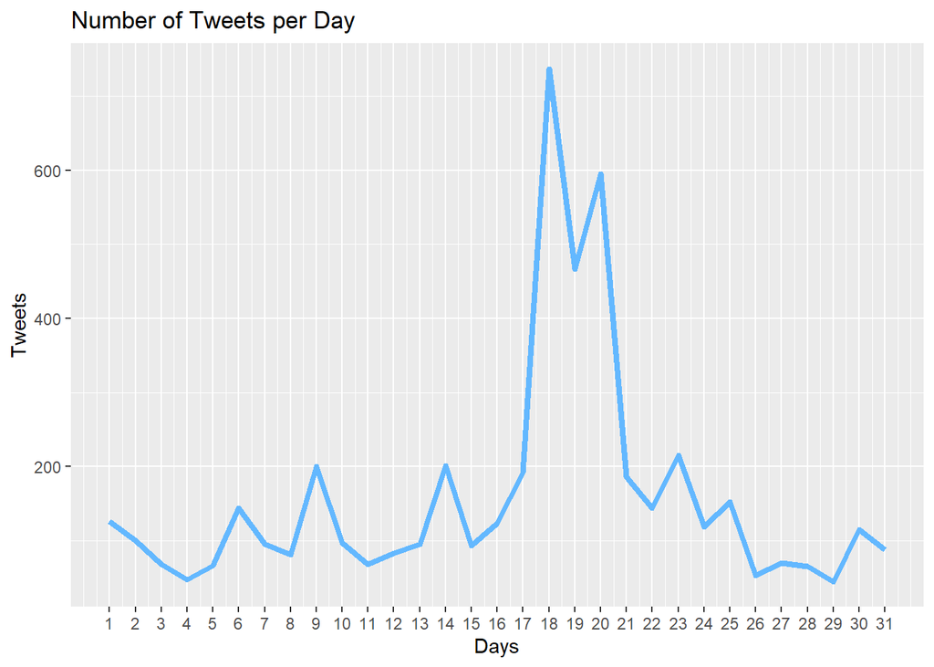

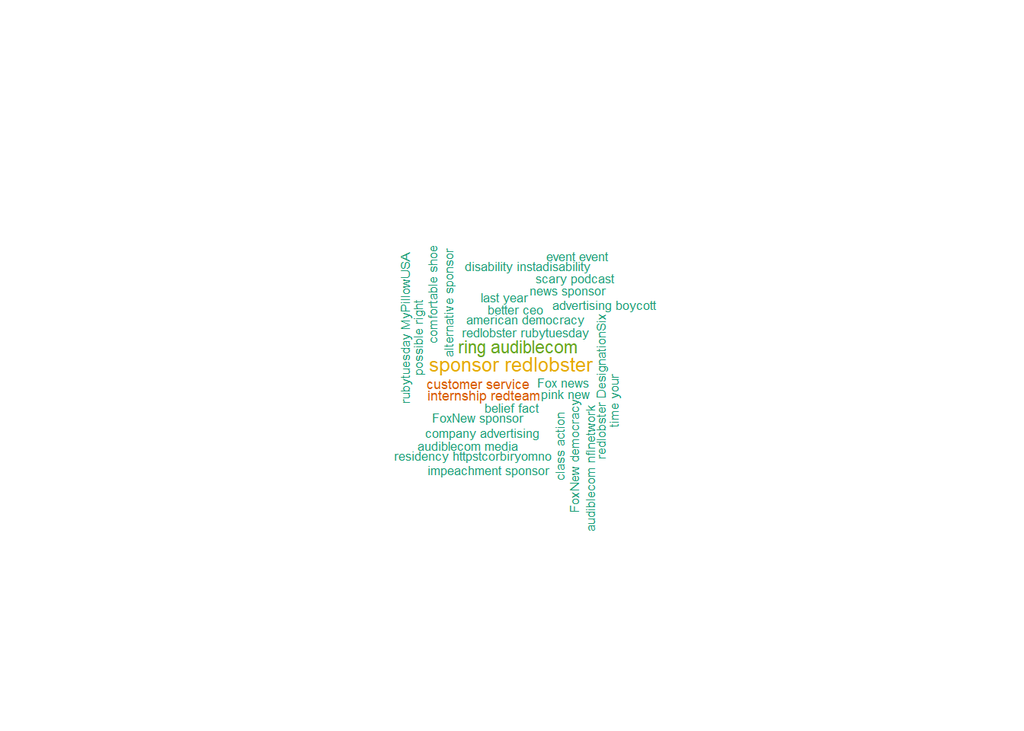

On the graph below, we can see that the user that tweeted the most about Zappos during the period of analysis were the ones with an iPhone. Then, surprisingly, more tweets came from the computer or the Web App than from Android. Finally, it is worth mentioning that iPad users are relevant, given that they are part of the top 4 users that tweeted the most.

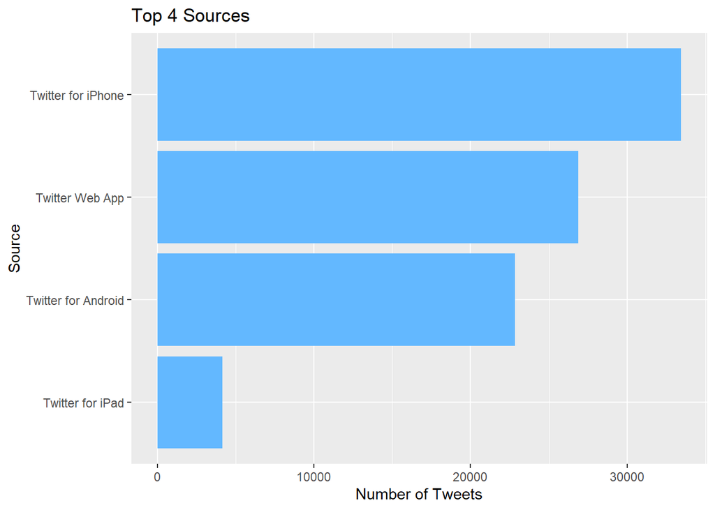

**Sentiment Analysis** **NRC Dictionary:**

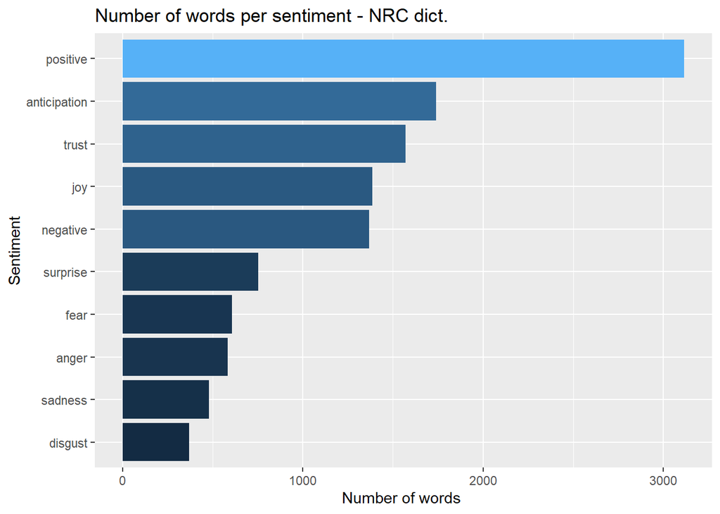

[interactive chart not shown]

In graph below, it can be seen that in the positive sentiment ‘money’ is the word that was mentioned the most, followed by ‘customer’ and ‘good’. From that, we can say that the company is performing well and that its mission is being reflected in this case because competitive prices and the high-quality customer service are part of their differentiation strategy.

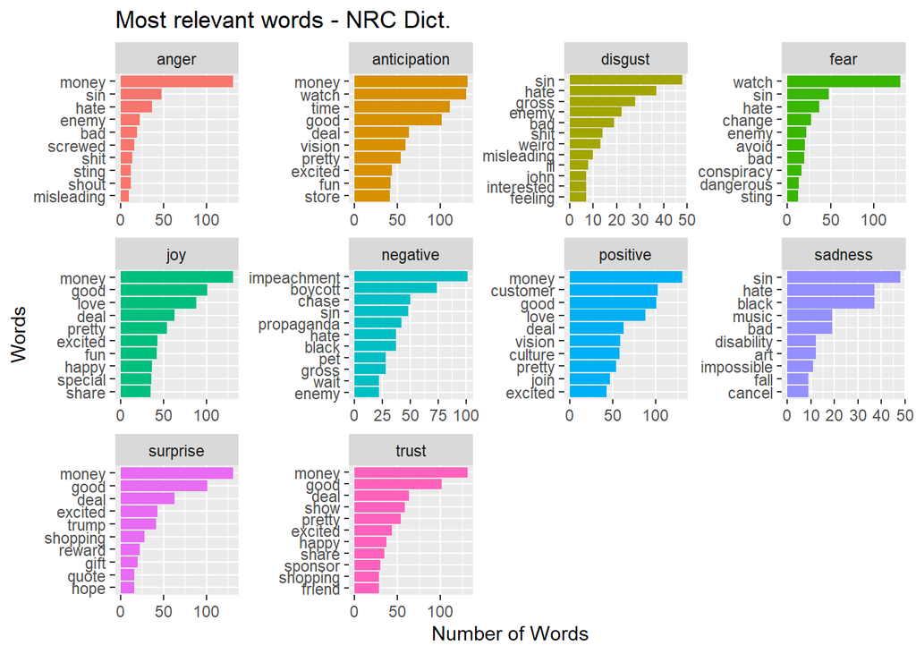

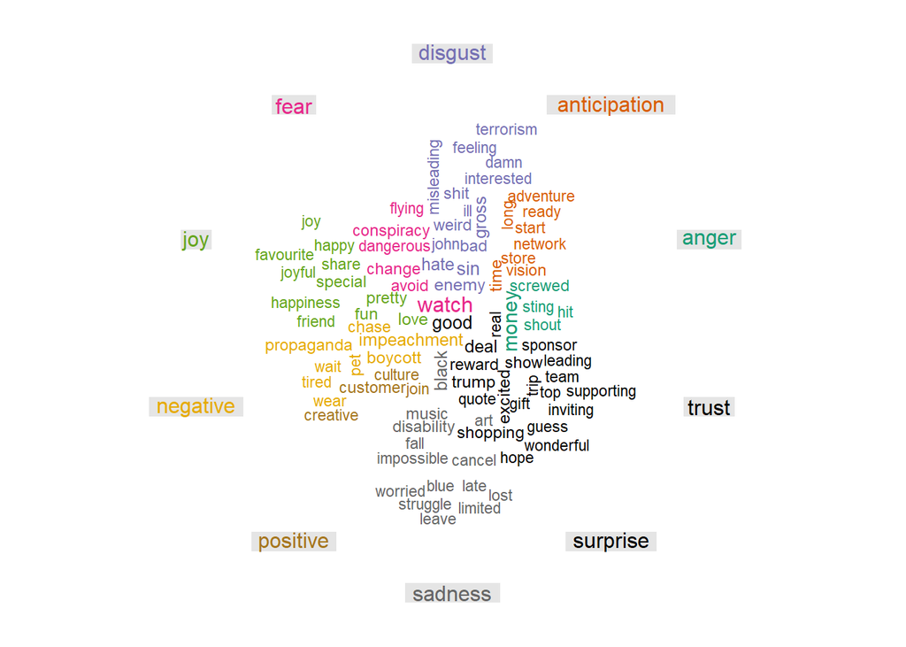

Moreover, the fact that words like ‘Culture’, ‘Vision’ and ‘Excited’ appear in other sentiments linked with positivism, leads us to the conclusion that the company’s users in twitter are satisfied and look up to the company.

Zappos should take into consideration that words like ‘Misleading’, ‘Hate’ and gross were mentioned too. As the analysis shows that the positive sentiment is a lot higher that the negative, the company can be relax about it, however it is important to have that in mind to keep improving the service and try to engage with this customer to change their minds.

In conclusion, the sentiment analysis conducted with the NRC dictionary shows that tweeter users that are tweeting about the company are rather satisfied with the service and that have a positive view of the firm.

**Sentiment Analysis** **Affin Dictionary:**

In the Sentiment Analysis conducted with the dictionary Affin, it can be seen that the positive sentiment outperforms the negative by big margin. In total, the Positive sentiment triple in points the Negative, which means that the company in the period of analysis is performing very well in this social media platform. It’s worth noting that for a company like Zappos the period of the end of December and January, is crucial. The demand in the industry is periodical and its highest peaked is at this time of the year.

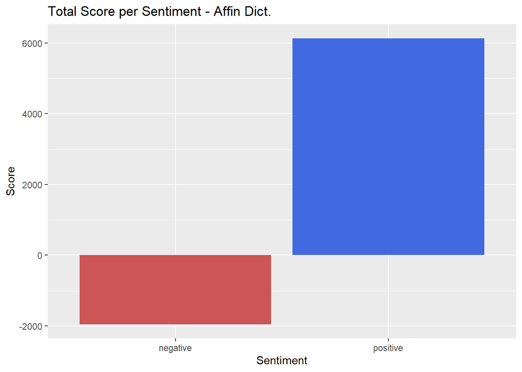

Going more into depth, we can see in Chart 4 that the word ‘Like’ is the one getting the highest score followed by ‘good’ and ‘love’. This shows that the company is having a very positive image among its tweeter users.

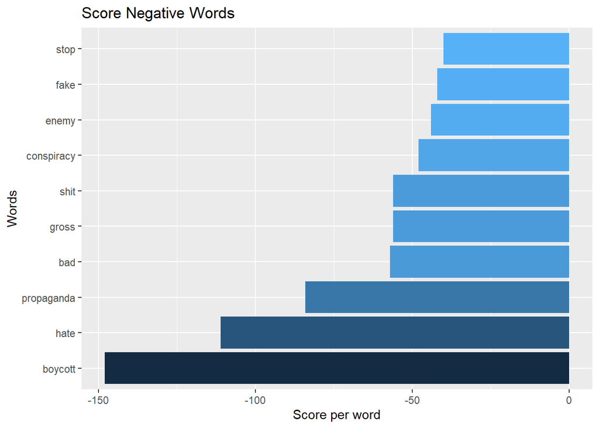

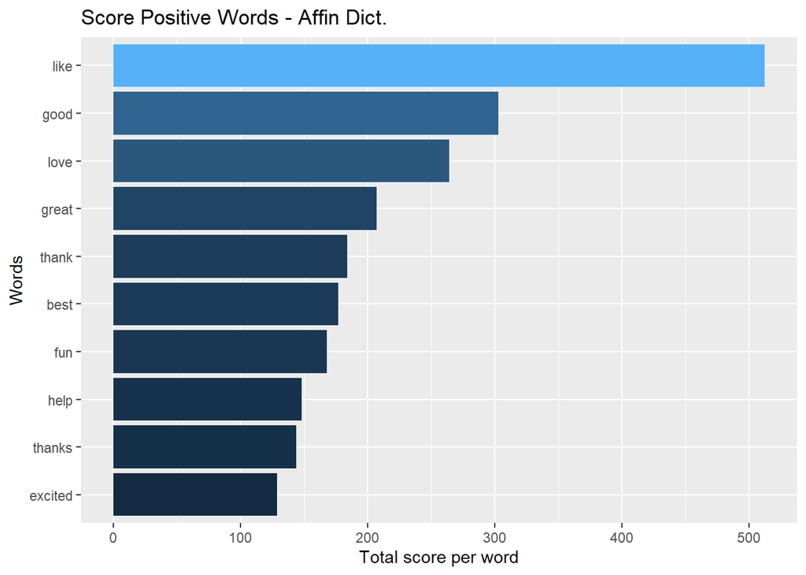

On the other hand, as can be seen in the graph below above that ‘boycott’ was the word with the highest negative score, followed by hate and propaganda. As the positive image was much bigger, the company should not worry too much about it, however, there is no harm in trying to approach the followers that used the word ‘hate’ and those that might have used propaganda in a negative way.

Finally, the graph below reconfirms that the positive sentiment; during the period of analysis, was constantly higher than the negative. Only on day 18 and 20 the negative score matched the positive, which means that the company, overall, is well regarded.

It is worth nothing that absolute value was used on the negative score for better representation on the graph below.

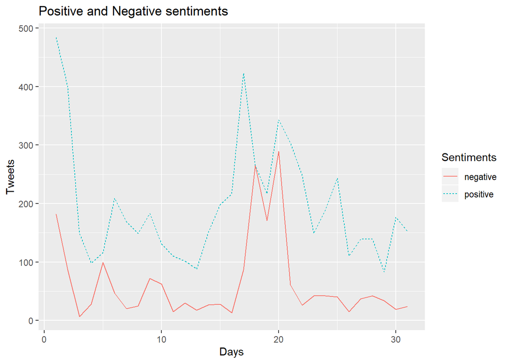

**Sentiment Analysis** **Bing Dictionary:**

In the Sentiment Analysis conducted with the dictionary Bing, it can be observed that overall, the positive sentiment is bigger and by a good margin that the negative. Chart 7 shows that in total, positive words were used twice as the negatives. Consequently, it is fair to say that the company is having a rather good performance in this social media platform.

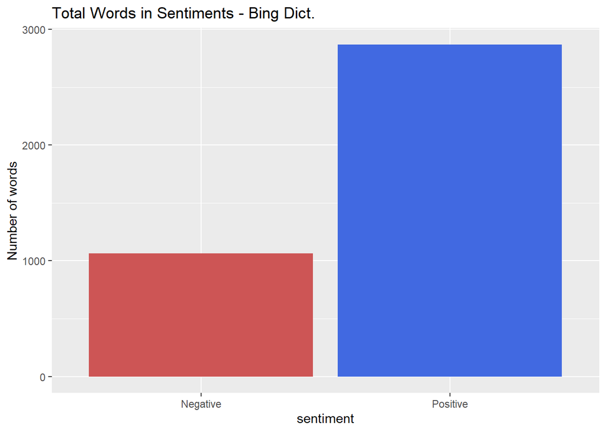

Chart 6 show us that ‘Like’ is the word most used, followed by audible and good. Those words transmit us that the user have a positive image of the company and that probably audible was a big hit during the month.

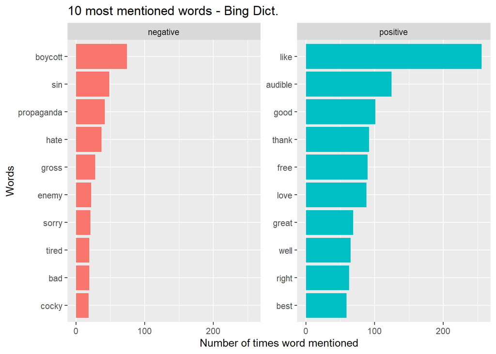

On the other hand, boycott was the most mentioned word in the negative sentiment. Followed by sin and propaganda. The company should take a look at this and try to engage with these followers to try to change their perspective.

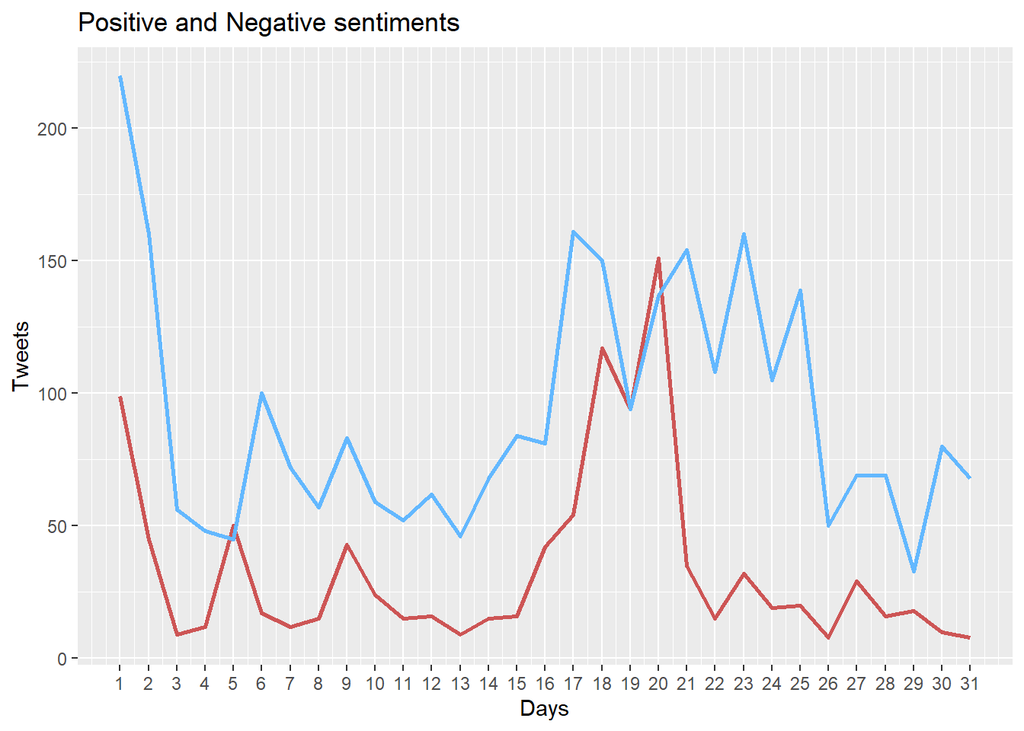

**Tweets made by Zappos Account** **Sentiment Anlysis**

**BING DICTIONARY:**

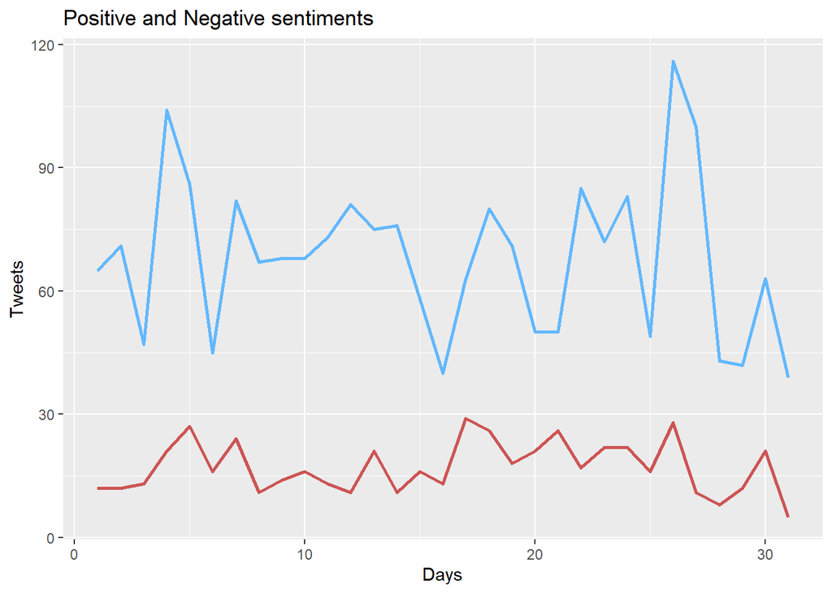

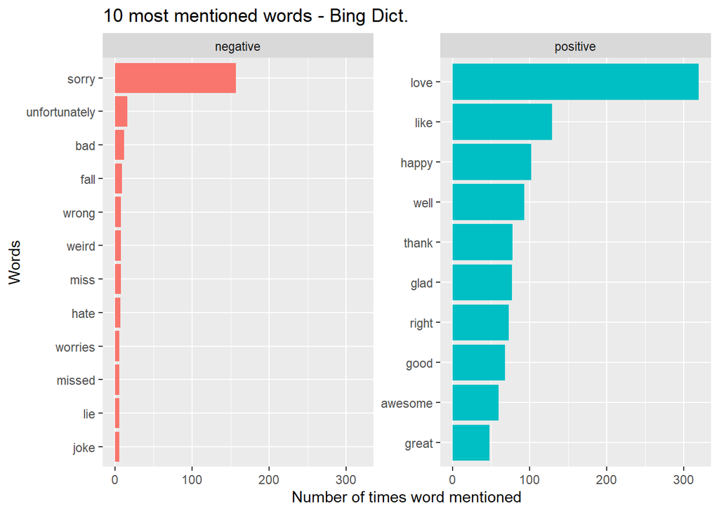

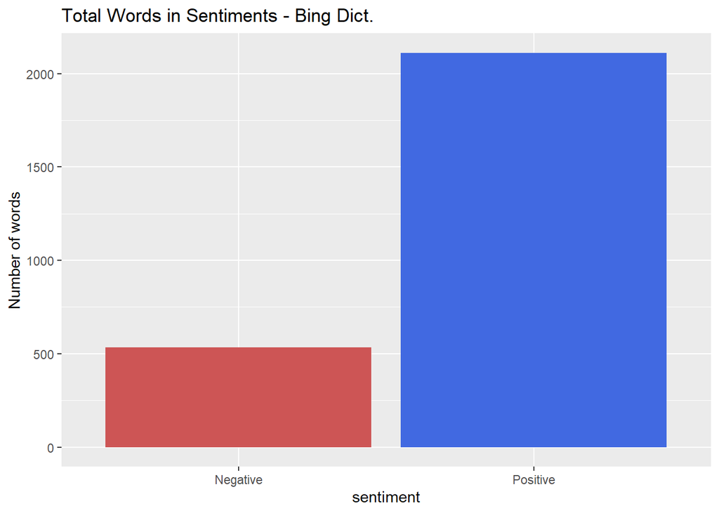

**Sentiment Analysis** **AFFIN Dictionary**

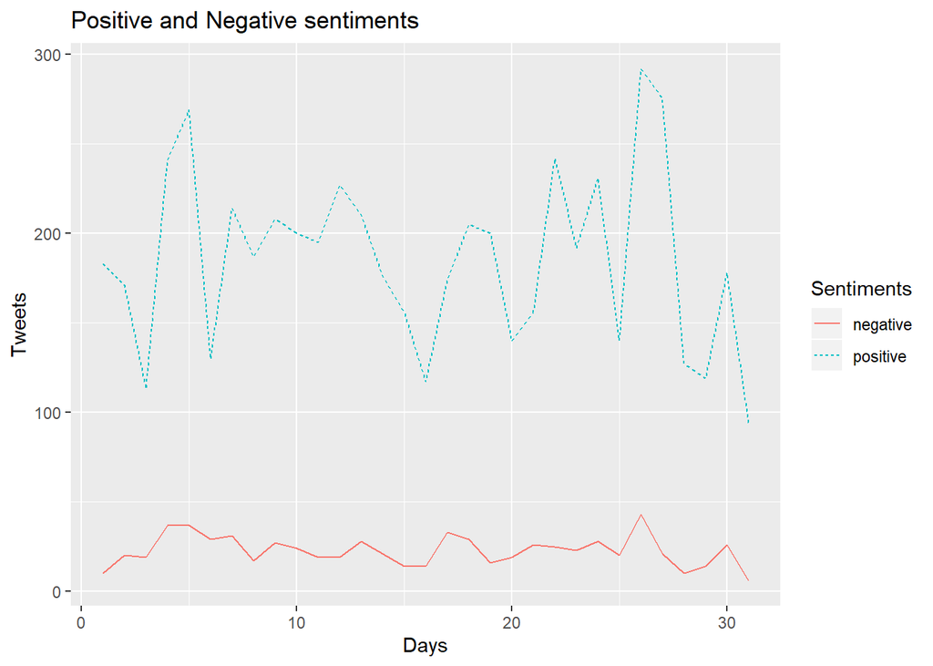

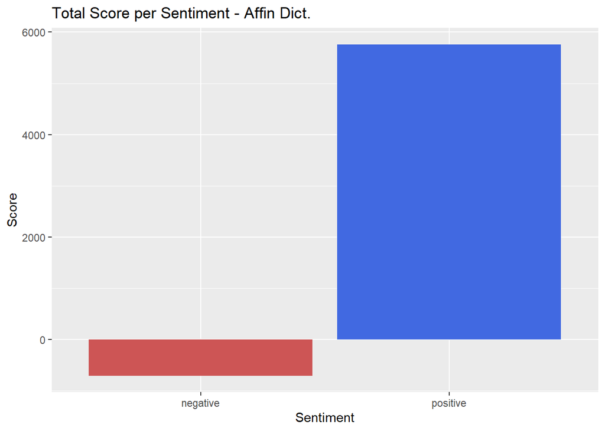

Moreover, the words that were labeled as positive and were used the most are ‘Love’, ‘Help’, and ‘Happy’. For the negative sentiment, ‘Sorry’, ‘ill’ and ‘Bad’ are the most frequent. From that, we can infer that the company mainly is approaching the customers for customer service and if not, they do it in a very friendly and respectful way.

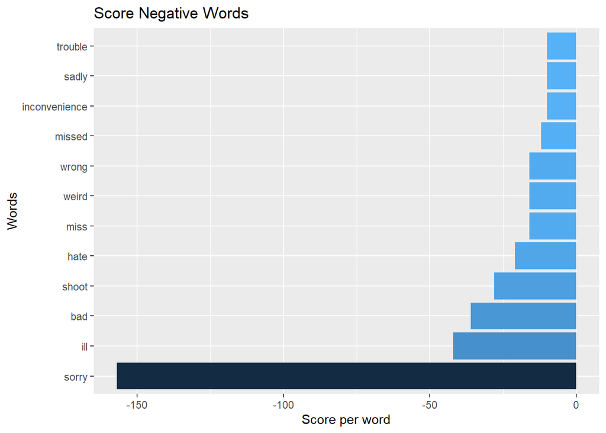

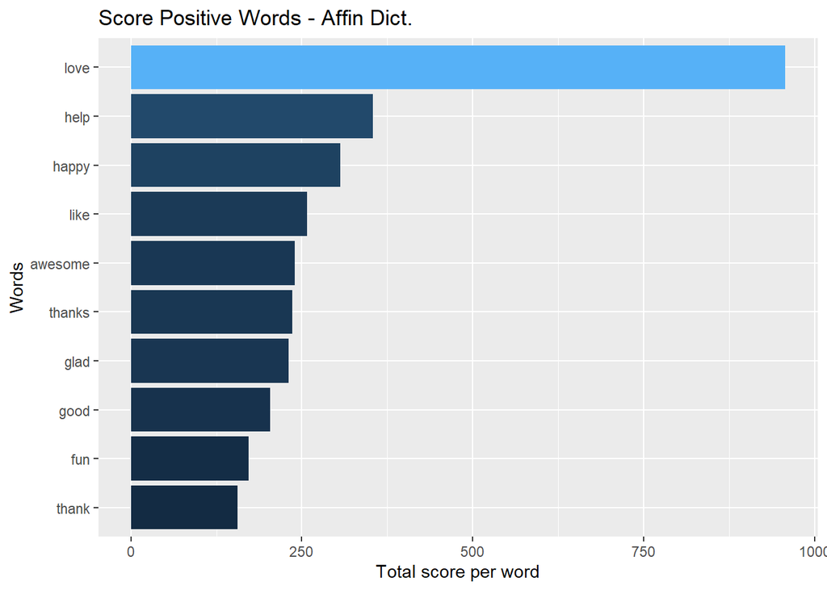

**Sentiment Analysis** **NRC Dictionary**

In the sentiment analysis conducted with the dictionary NRC of the tweets made by the company, the results show that the positive sentiment is the predominant. Also, the ones that follow it are quite linked to it, like Joy and Anticipation. This means, that the company mostly twitting in a very friendly, close and respectful manner.

[interactive chart not shown]

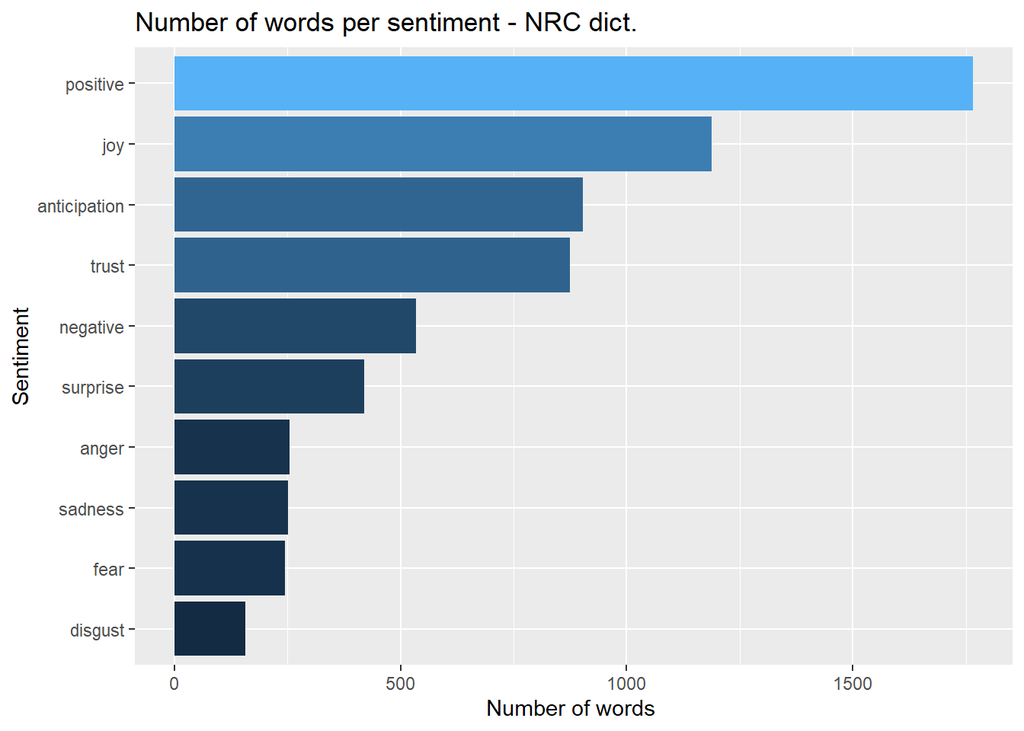

The words that were used the most are in the positive sentiment were ‘Love’, ‘Happy’ and ‘Glad’. On the other hand, in the negative sentiment, the word that was used the most is ‘Wait’ and it’s followed by ‘Shoot’. We can infer that the company is communication on this platform always in a positive way and that even what is labeled as ‘Negative’ is actually very neutral.

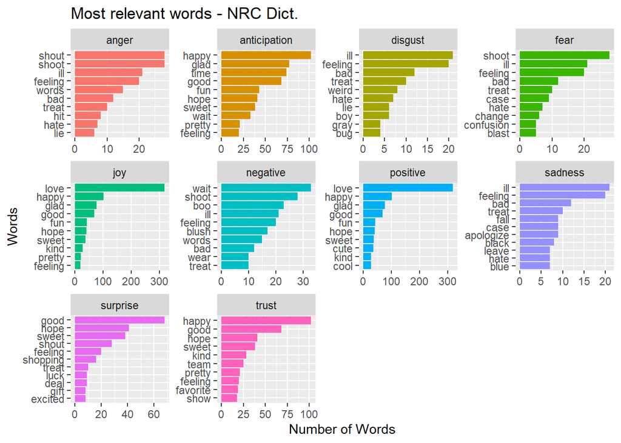

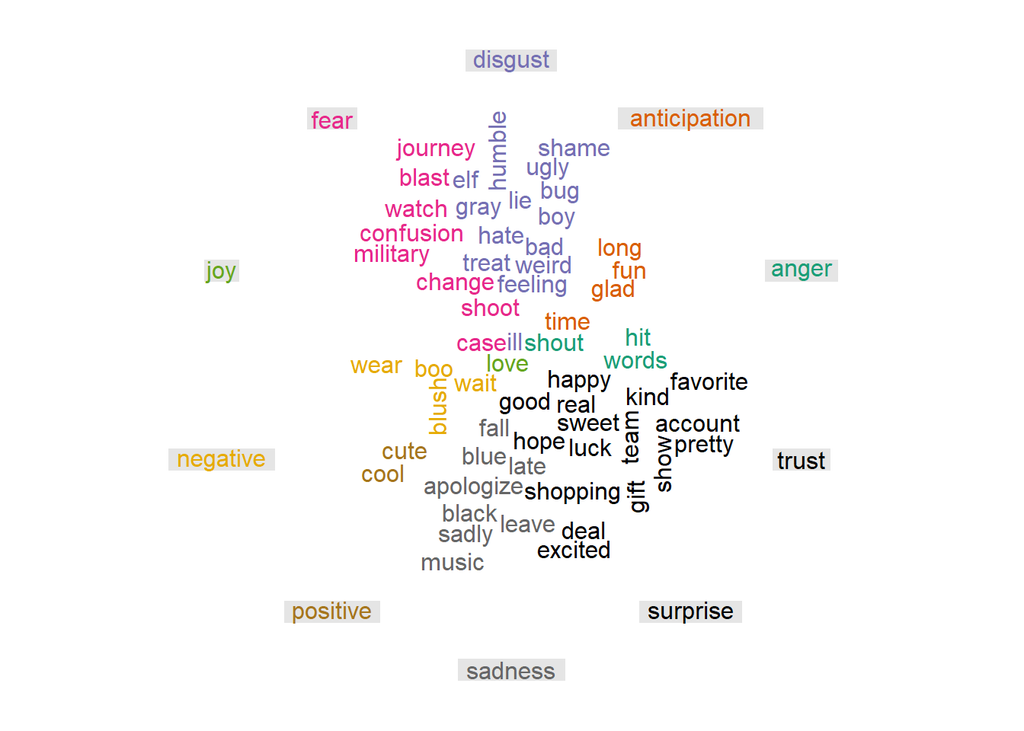

**Zappos Followers Account Analysis:**

So part of our analysis is to analyze the followers of Zappos twitter account and do some descriptive analysis on them. We classify followers into active, passive and normal users. We use the rule <5000 post is passive, from 5000 to 15000 is normal, and greater than 15000 is active.

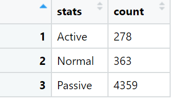

Activity status split.

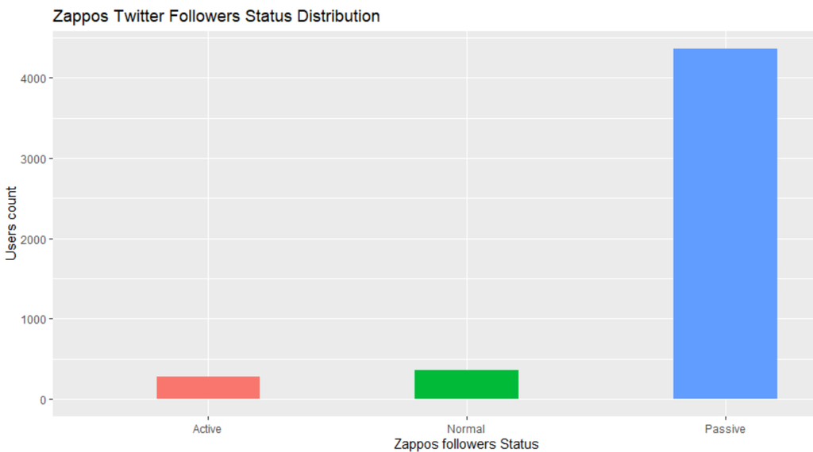

Activity status split.

Using the get_followers(), we got 5000 accounts with 90 variables. Out of those 90 variables we kept the most relevant ones and ended up with 17 variables

o User_id

o Created_at

o Screen_name

o Source

o Lang

o Country

o Country_code

o Name

o Location

o Followers_count

o Friends_count

o Statuses_count

o Favourites_count

o Account_created_at

o Verified

o Account_lang

o text

So we started by analyzing which language is spoken most by the followers . Almost 3000 of Zappos followers speaks English. Then English is followed by Spanish and then Portuguese. (UND stands for undetermined )

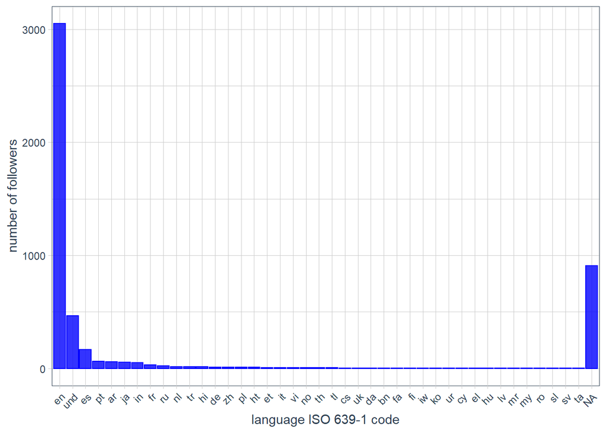

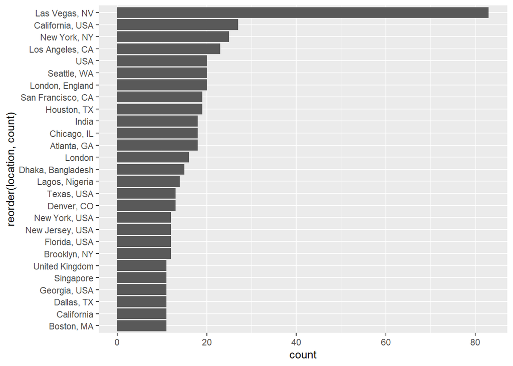

So looks like most of the followers are based in Las Vegas, followed by California and New York. And this could lead to a further analysis that usually Zappos followers tend to have a good salary based on the fact that the upper range of states in the graph are quite expensive and have a high quality of living standards compared to other stats.

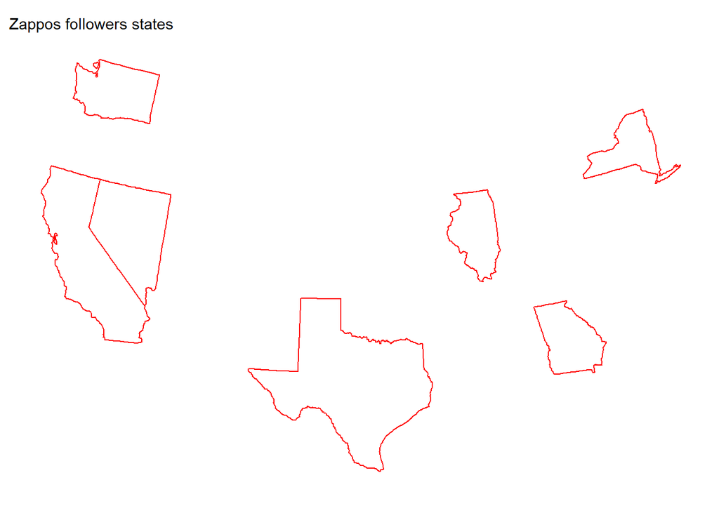

In this chart, we analyze how many of Zappos followers are verified users.

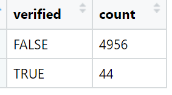

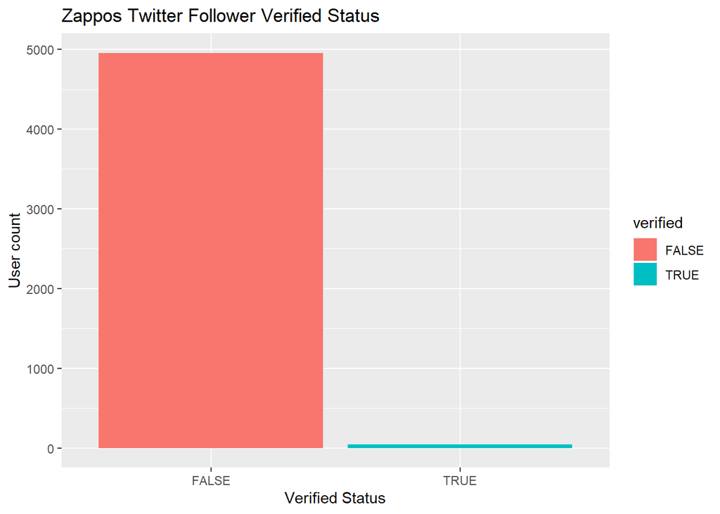

Here we perform a status correlation: We will investigate the relationships between among the continuous variables, namely Statuses_Count, Followers_Count, favorites_Count and friends_Count. From the correlation table we can see all of them share a positive correlation, however, followers_ count and friends_count are mostly correlated, approximately 0.9.

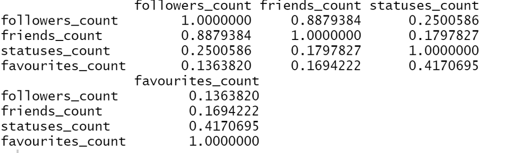

Followers_count: how many followers do they have